# Filter AquaMatch Data

B Steele, Colorado State University, ROSSyndicate

last updated Sept 15, 2026

This step applies some filters to the SDD and siteSR data.

## Setup

```r
# load libraries
library(igraph)
library(parallel)
library(arrow)
library(sf)
library(tigris)
library(hydrogeofetch) # NHD/WBD fetch toolchain - used below for get_huc()
library(tidyverse)

aquamatch_raw_data_dir <- "regional_clarity/aquamatch_files/downloads"
filtered_aquamatch_dir <- "regional_clarity/aquamatch_files"
```

## Regional AOI

Every filter below (SDD quality/RANSAC filtering, siteSR outlier filtering) operates per-site and needs no broader/national context, so we determine our 6-state region’s HUC4 footprint here, up front, and scope both pipelines down to it before any of the expensive per-site processing runs - rather than waiting until `02_make_matches.Rmd` to subset down to it after matching and after the costly RANSAC fits have already run on out-of-region data.

```r
states <- states(progress_bar = FALSE) %>%
  filter(STUSPS %in% c("CO", "WY", "UT", "ID", "MT", "NM"))
states_union <- states %>% st_union()
```

Grab all the HUC4’s touching our 6-state AOI. We prefer a live NHD/WBD query via `hydrogeofetch::get_huc()`; that service has intermittently timed out against the USGS pygeoapi backend in the past (even retried state-by-state), so we cap it at 30 seconds and fall back to the WBD national geodatabase already cached locally (`aquamatch_files/wbd_national`) if it errors or doesn’t return in time.

```r
huc4_cache_gdb <- file.path(filtered_aquamatch_dir,
                            "wbd_national/WBD_National_GDB/WBD_National_GDB.gdb")

HUC4_national <- tryCatch(
  # run get_huc() in a subprocess (not a signal-based timeout in this
  # session) - interrupting a GDAL/curl call mid-flight in-process can leave
  # the driver in a bad state for the fallback st_read() below; a subprocess
  # can just be killed cleanly on timeout instead
  callr::r(
    function(aoi) {
      library(hydrogeofetch)
      get_huc(AOI = aoi, type = "huc04")
    },
    args = list(aoi = states_union),
    timeout = 30
  ),
  error = function(e) {
    message("Live HUC4 fetch failed or timed out (", conditionMessage(e),
            "); falling back to the cached WBD national geodatabase.")
    st_read(huc4_cache_gdb, layer = "WBDHU4", quiet = TRUE) %>%
      # WBD ships with Z values and a compound CRS (NAD83 + NAVD88 height);
      # transforming a 2D CRS into that compound CRS silently breaks (no
      # vertical grid to invent a Z), so drop Z here - horizontal datum is
      # then plain NAD83
      st_zm(drop = TRUE, what = "ZM") %>%
      rename_with(tolower)
  }
)
```

```
## Live HUC4 fetch failed or timed out (! callr timed out); falling back to the cached WBD national geodatabase.
```

```r
# standardize the geometry column name to "geometry" (FileGDB layers are
# often read in with the geometry column named "shape"; get_huc() already
# names it "geometry")
geom_col <- attr(HUC4_national, "sf_column")
if (geom_col != "geometry") {
  names(HUC4_national)[names(HUC4_national) == geom_col] <- "geometry"
  st_geometry(HUC4_national) <- "geometry"
}

# reduce from the national/live layer to just the HUC4's touching our
# 6-state AOI
HUC4v <- HUC4_national %>%
  st_transform(st_crs(states_union)) %>%
  st_make_valid() %>%
  st_filter(states_union)
```

And then assess overlapping area - here we want to include HUCs that overlap the 6-state area by at least 50%.

```r
overlap_areas <- st_make_valid(HUC4v) %>%
  st_intersection(st_make_valid(states_union)) %>%
  mutate(overlap_area = st_area(geometry)) %>%
  st_drop_geometry() %>%
  select(huc4, overlap_area)
# calculate proportion overlap, filter for those greater than/equal to 50%
HUC4_filtered <- HUC4v %>%
  left_join(overlap_areas, by = "huc4") %>%
  mutate(
    overlap_area = coalesce(overlap_area, units::set_units(0, "m^2")),
    overlap_frac = as.numeric(overlap_area / st_area(geometry))
  ) %>%
  filter(overlap_frac >= 0.50)
```

Save the HUC4 and state boundaries as their own geodatabases so this and later scripts can just read these back in instead of re-running the HUC4 download/filter and `states()` pull.

```r
st_write(HUC4_filtered,
         dsn = file.path(filtered_aquamatch_dir, "huc4_filtered.gdb"),
         layer = "huc4_filtered",
         driver = "OpenFileGDB",
         append = FALSE,
         quiet = TRUE)

st_write(states,
         dsn = file.path(filtered_aquamatch_dir, "states.gdb"),
         layer = "states",
         driver = "OpenFileGDB",
         append = FALSE,
         quiet = TRUE)
```

Initialize a row-count log to track how much data survives each filtering step below, so we can summarize retention/loss once the full pipeline (through `02_make_matches.Rmd`) has run.

```r
row_log <- tibble(pipeline = character(), step = character(),
                  n_rows = double(), n_sites = double())

log_step <- function(log, pipeline, step, n_rows, n_sites = NA_real_) {
  bind_rows(log, tibble(pipeline = pipeline, step = step,
                        n_rows = n_rows, n_sites = n_sites))
}
```

## SDD data filtering

This section applies a ransac-style filter to sites with greater numbers of SDD observations to remove obvious outliers based on historical patterns and trends.

```r
sdd_raw_path <- file.path(aquamatch_raw_data_dir, "sdd_cache.parquet")

sdd <- open_dataset(sdd_raw_path)

sdd_filtered_path <- file.path(filtered_aquamatch_dir, "sdd_quality_filter.parquet")

row_log <- log_step(row_log, "SDD", "0_raw_nationwide",
                    n_rows = sdd %>% summarize(n = n()) %>% collect() %>% pull(n))

sdd_qc <- sdd %>%
  filter(
    # do some SDD filters - must be in higher tiers of data
    tier < 3,
    # must have a reasonable  value
    harmonized_value >= 0.1,
    # if there are aggregated rows, they generally agree
    harmonized_value_cv <= 0.25 | is.na(harmonized_value_cv),
    # no flags
    misc_flag == 0,
    # not a bottom hit
    depth_flag == 0,
    # and we'll just grab lake/res/impoundment data
    ResolvedMonitoringLocationTypeName == "Lake, Reservoir, Impoundment"
  ) %>%
  collect()

row_log <- log_step(row_log, "SDD", "1_quality_tier_flag_filters",
                    n_rows = nrow(sdd_qc),
                    n_sites = n_distinct(sdd_qc$MonitoringLocationIdentifier))

# restrict to sites within our 6-state region's HUC4 footprint (see
# "Regional AOI" above) - RANSAC and everything else here runs per-site, so
# there's no reason to spend time fitting sites this project will never use
sdd_site_pts <- sdd_qc %>%
  distinct(MonitoringLocationIdentifier, lat, lon) %>%
  st_as_sf(coords = c("lon", "lat"), crs = 4326, remove = FALSE) %>%
  st_transform(st_crs(HUC4_filtered)) %>%
  st_filter(HUC4_filtered)

sdd_qc <- sdd_qc %>%
  filter(MonitoringLocationIdentifier %in% sdd_site_pts$MonitoringLocationIdentifier)

row_log <- log_step(row_log, "SDD", "2_regional_HUC4_restriction",
                    n_rows = nrow(sdd_qc),
                    n_sites = n_distinct(sdd_qc$MonitoringLocationIdentifier))

# run a ransac-like algorithm per site to remove outliers
ransac_site <- function(date, one_site_sdd,
                        n_iter = 50,
                        mad_thresh = 2,
                        n_sd = 3,
                        range_buffer_frac = 0.15,
                        min_diff = 1,
                        min_sample = 10,
                        vote_frac = 0.6) {
  n <- length(one_site_sdd)
  if (n < min_sample + 1) return(rep(NA, n))  # too few points to run ransac

  t <- as.numeric(date)
  # tally, per point, how many valid iterations called it an inlier
  inlier_votes <- rep(0L, n)
  n_valid_iter <- 0L

  for (i in 1:n_iter) {
    idx <- sample(n, min_sample)
    if (length(unique(t[idx])) < 2) next  # avoid degenerate fit (same date)
    out_idx <- setdiff(seq_len(n), idx)

    fit <- lm(one_site_sdd[idx] ~ t[idx])
    pred <- coef(fit)[1] + coef(fit)[2] * t
    resid <- one_site_sdd - pred
    # scale should come from held-out points only - points used to fit the
    # line have near-zero residual by construction, so including them
    # deflates the scale (and threshold) whenever min_sample is close to n,
    # making a single held-out point look like an outlier over a trivial
    # difference. use MAD rather than sd() here: sd() is itself inflated by
    # a cluster of genuine outliers landing in the held-out set (a handful of
    # large same-direction residuals drag the mean and blow up the squared
    # deviations), which loosens the threshold and lets that same cluster
    # vote itself in as inliers. MAD is robust to that as long as the
    # cluster is a minority of the held-out set, since it centers on the
    # median rather than the mean.
    resid_scale <- if (length(out_idx) >= 2) {
      mad(resid[out_idx], constant = mad_thresh, na.rm = TRUE)
    } else {
      # too few held-out points (n == min_sample + 1) to trust their own MAD -
      # fall back to all-points MAD (deflated, but not degenerate) instead
      mad(resid, constant = mad_thresh, na.rm = TRUE)
    }
    # never flag a point closer than min_diff to the fit line, regardless of
    # how tight the scale-based threshold is - a < 1 m disagreement isn't
    # meaningfully an outlier for Secchi depth.
    threshold <- max(n_sd * resid_scale, min_diff, na.rm = TRUE)
    inliers <- !is.na(resid) & abs(resid) < threshold

    inlier_votes <- inlier_votes + as.integer(inliers)
    n_valid_iter <- n_valid_iter + 1L
  }

  # indicate when no iteration ever produced a usable fit
  if (n_valid_iter == 0) return(rep(NA, n))

  # a point is an inlier if at least vote_frac of the valid iterations agreed
  best_inliers <- (inlier_votes / n_valid_iter) >= vote_frac

  # a flagged point can't be implausible for this site if its value falls
  # within the range other accepted (inlier) observations already span here -
  # deviating from the local trend line isn't grounds to flag it when the
  # site itself has already produced values in that range. this matters most
  # for low-n sites, where a short fit sample leaves little room to
  # distinguish a real trend from a value the site has simply shown before
  if (any(best_inliers)) {
    inlier_range <- range(one_site_sdd[best_inliers], na.rm = TRUE)
    # scale the buffer to this site's typical SDD rather than using a flat
    # meters value - 0.5 m is a huge margin at a 1 m-visibility site and
    # negligible at a 10 m-visibility site
    range_buffer <- range_buffer_frac * mean(one_site_sdd[best_inliers], na.rm = TRUE)
    best_inliers <- best_inliers | (one_site_sdd >= inlier_range[1] + range_buffer &
                                      one_site_sdd <= inlier_range[2] - range_buffer)
  }

  best_inliers
}


if (!file.exists(sdd_filtered_path)) {
  set.seed(43)
  sdd_qc %>%
    arrange(harmonized_local_time)%>%
    mutate(is_inlier = ransac_site(harmonized_local_time, harmonized_value),
           .by = MonitoringLocationIdentifier) %>%
    # also reverse the flag in cases where multiple measurements are made
    # since we've already confirmed multiple measurements agree (value_cv <= 0.25)
    mutate(is_inlier = if_else(harmonized_row_count > 1 &
                                 (!is_inlier | is.na(is_inlier)),
                               TRUE,
                               is_inlier)) %>%
    write_parquet(sdd_filtered_path)
}
```

Check whether flagging concentrates at the SDD extremes rather than spreading evenly across the distribution. A high-end concentration here isn’t necessarily a problem here: we expect a lot of what lands in the far right tail of raw SDD is genuinely implausible (deeper than the water body, deeper than the instrument’s rope, transcription errors, etc.) rather than real high-clarity variability - the point of this check is to tell those two cases apart before trusting the filter.

```r
sdd_ransac_check <- read_parquet(sdd_filtered_path)
```

Let’s look at highly-flagged sites as a spot-check.

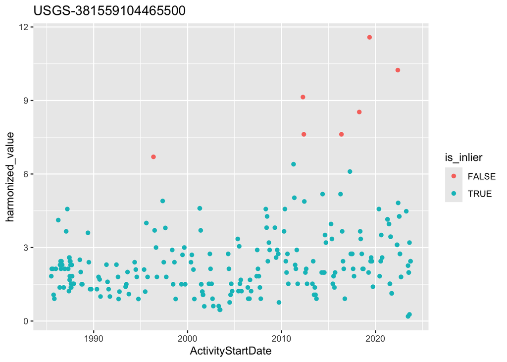

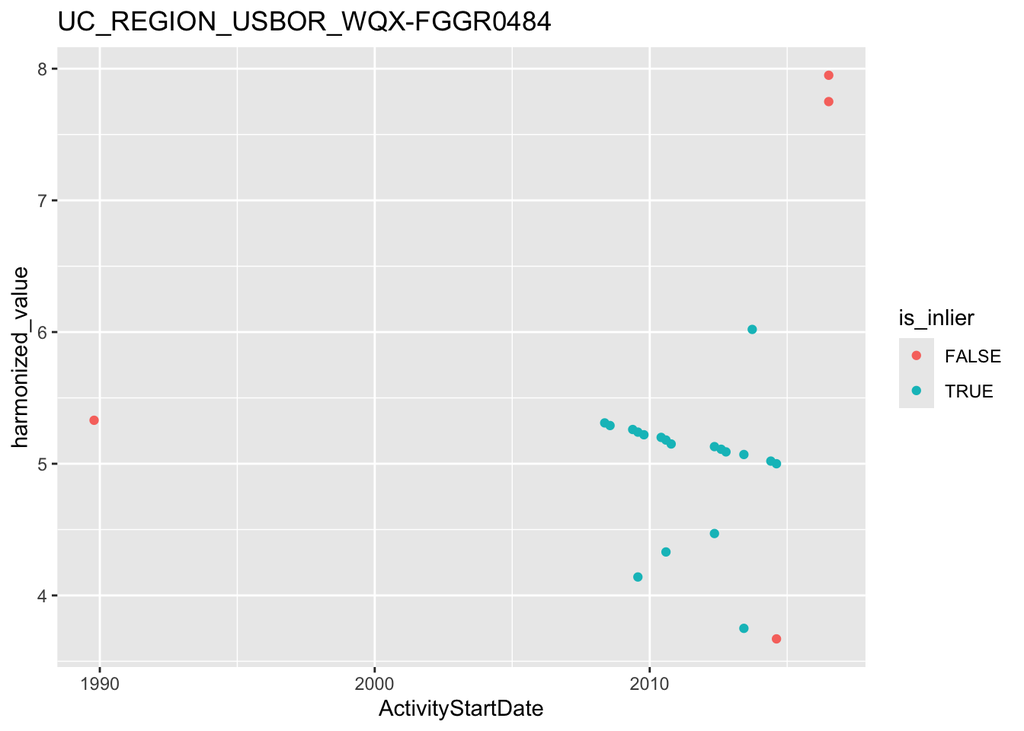

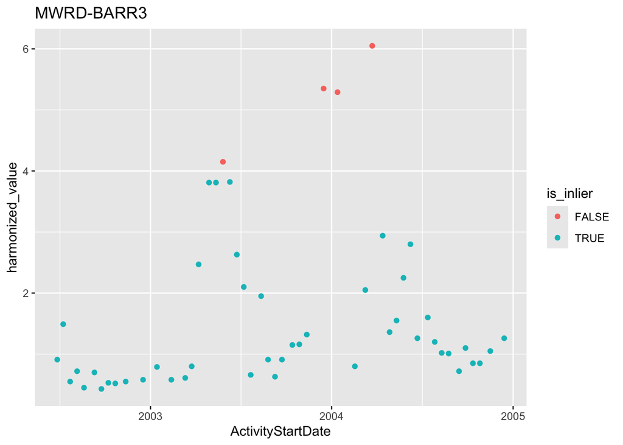

```r
high_flag_sites <- sdd_ransac_check %>%
  summarize(n = n(),
            n_flagged = sum(is_inlier == FALSE),
            mean_sdd = mean(harmonized_value),
            .by = c(MonitoringLocationIdentifier, lat, lon)) %>%
  arrange(-n_flagged) %>%
  filter(n_flagged >= 4)

map(.x = high_flag_sites$MonitoringLocationIdentifier,
    ~ sdd_ransac_check %>%
      filter(MonitoringLocationIdentifier == .x) %>%
      ggplot(., aes(x = ActivityStartDate,
                    y = harmonized_value,
                    color = is_inlier)) +
      geom_point() +
      labs(title = .x))
```

There are clearly a couple overflagging examples here, but it’s a bit out of scope to refine the ransac futher.

```r
# rows that will actually reach 02_make_matches.Rmd - is_inlier == FALSE is
# excluded there before matching; NA (RANSAC never resolved, e.g. too few
# points) is kept, same treatment as the siteSR band RANSAC below
sdd_for_matching <- sdd_ransac_check %>%
  filter(is_inlier | is.na(is_inlier))

row_log <- log_step(row_log, "SDD", "3_ransac_inliers_for_matching",
                    n_rows = nrow(sdd_for_matching),
                    n_sites = n_distinct(sdd_for_matching$MonitoringLocationIdentifier))
```

Re-summarize and look again:

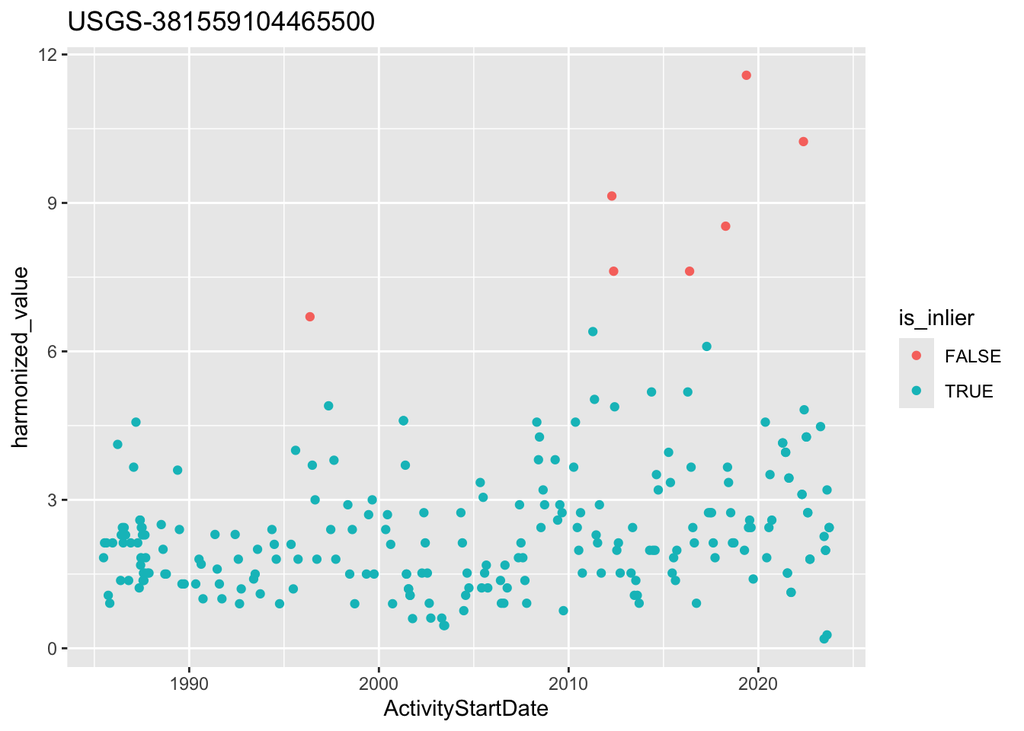

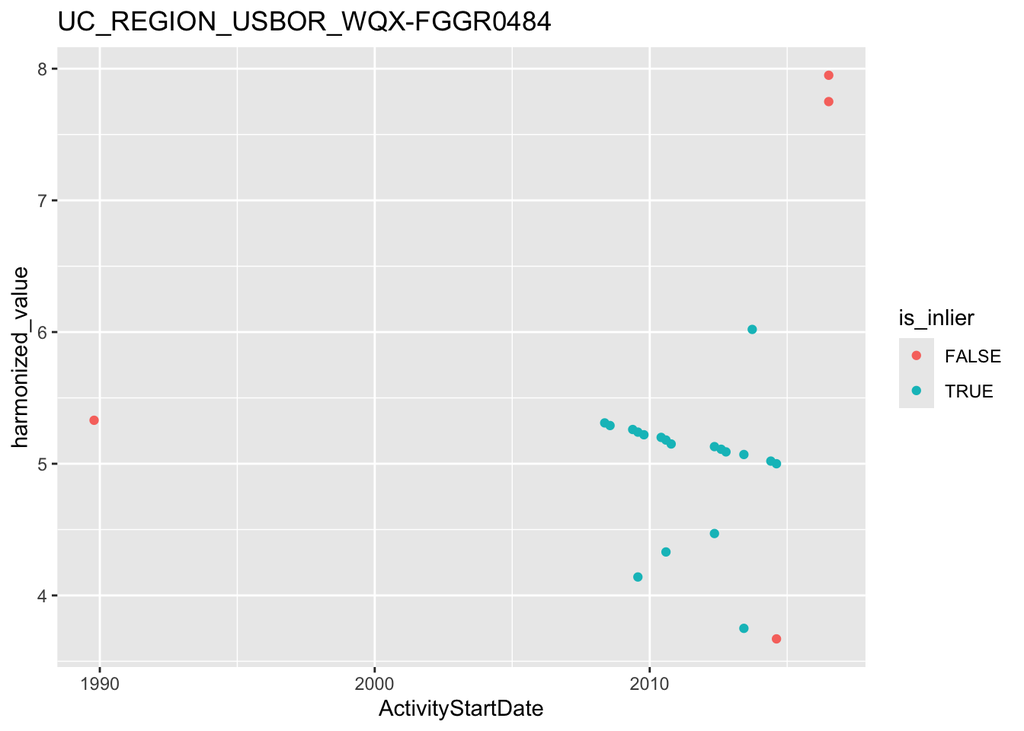

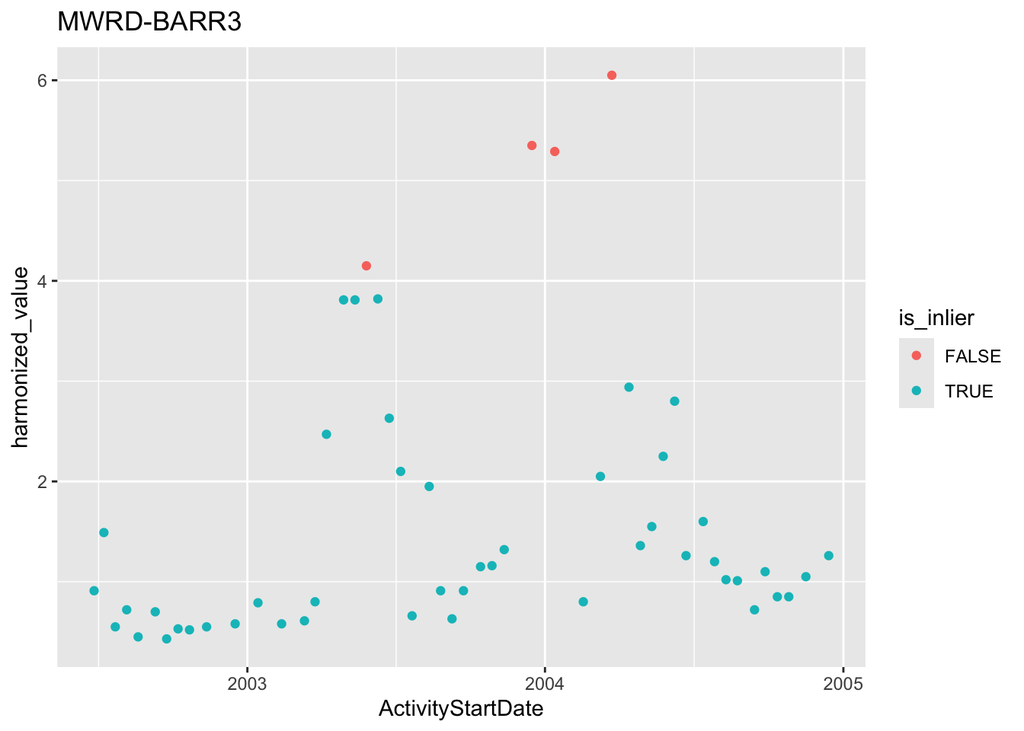

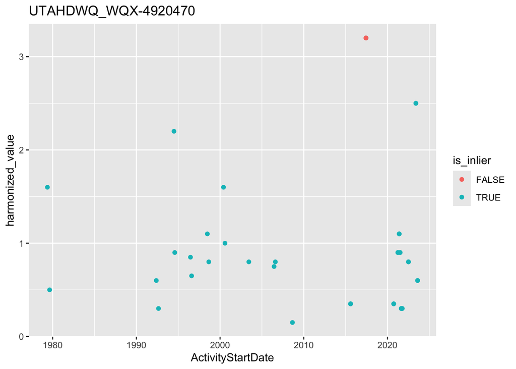

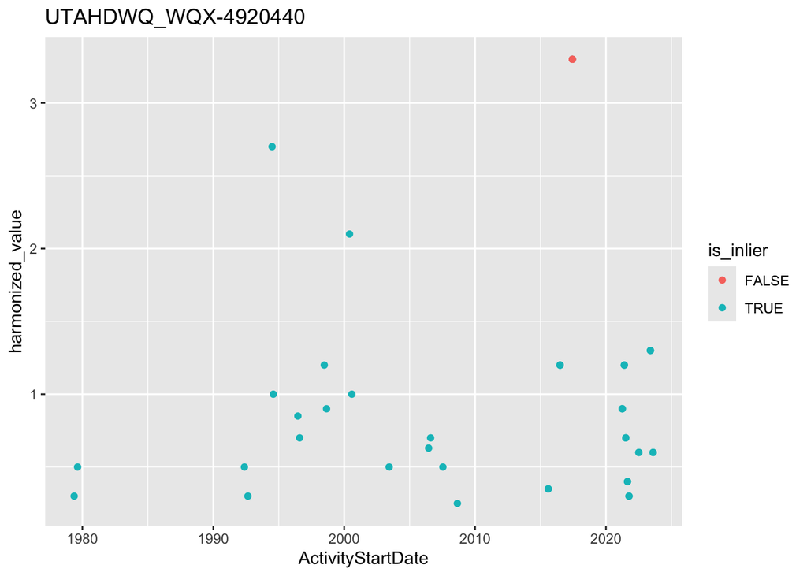

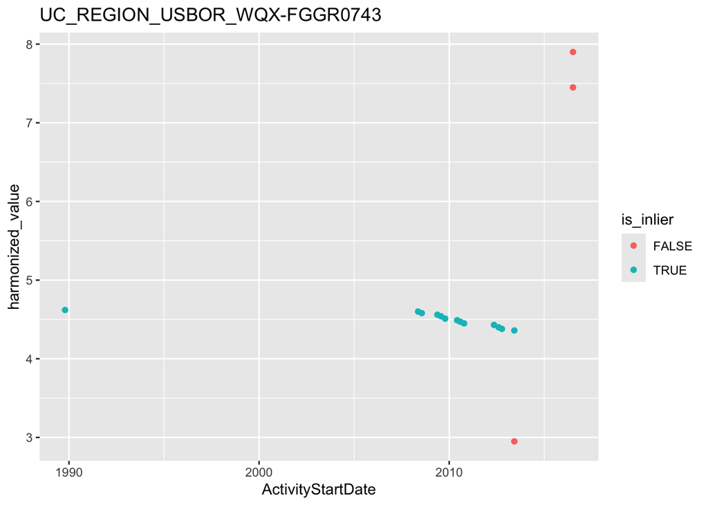

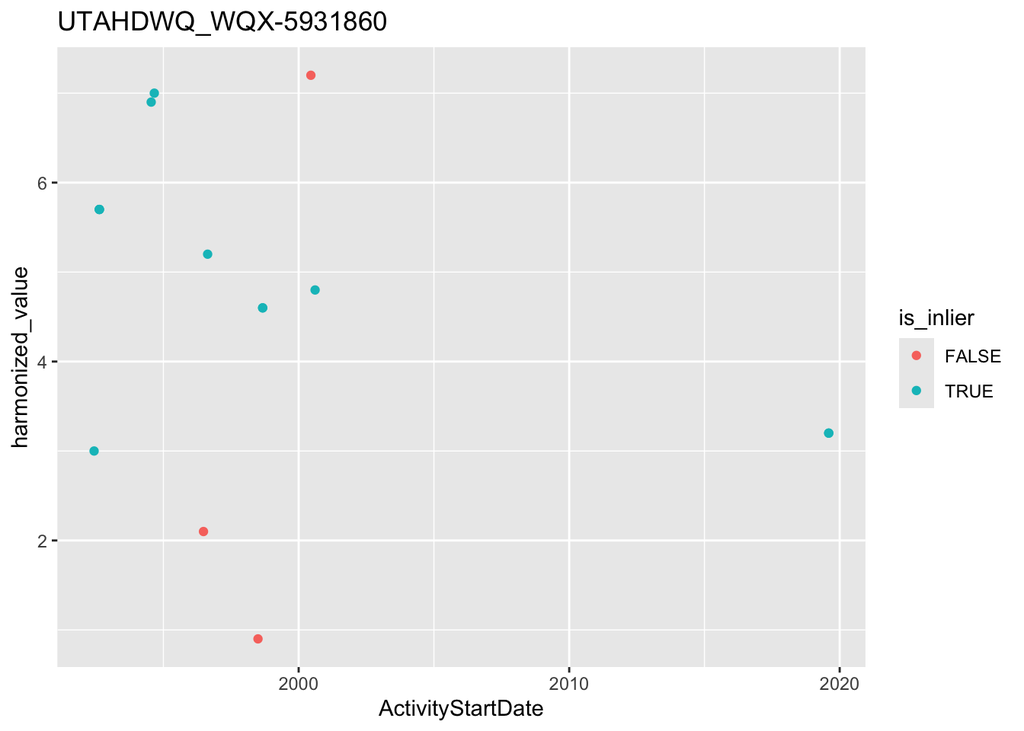

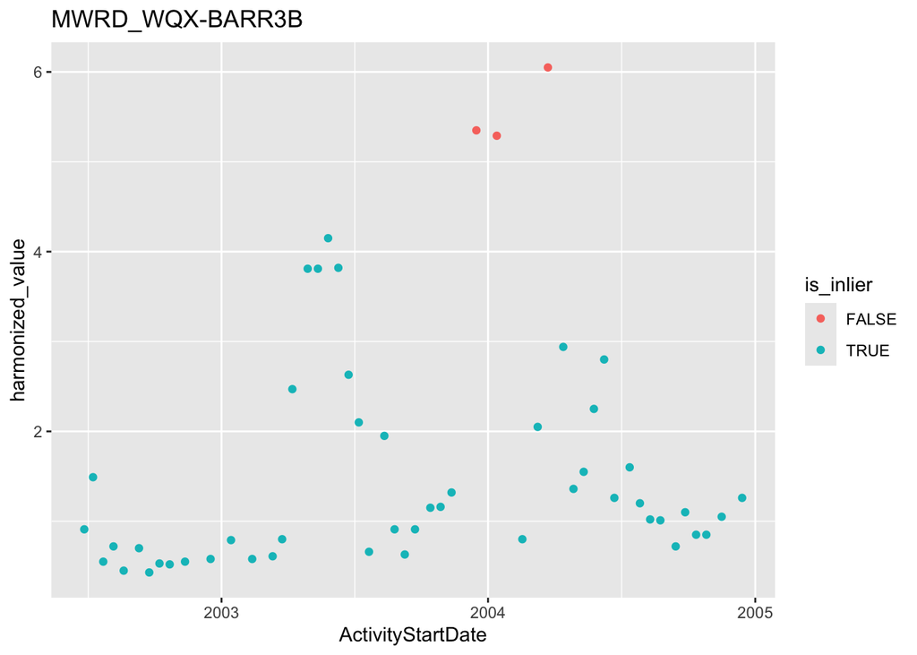

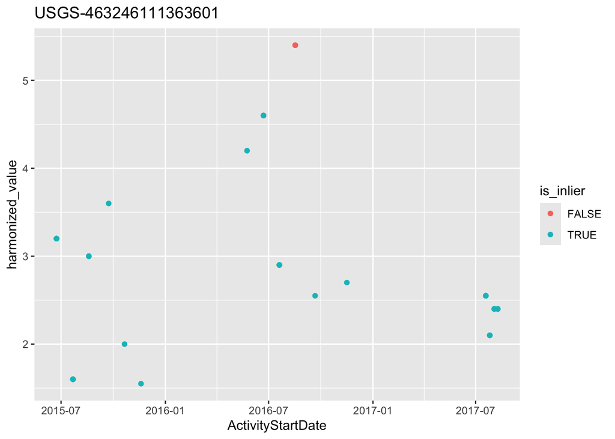

```r
high_flag_sites <- sdd_ransac_check %>%
  summarize(n = n(),
            n_flagged = sum(is_inlier == FALSE),
            mean_sdd = mean(harmonized_value),
            .by = c(MonitoringLocationIdentifier, lat, lon)) %>%
  arrange(-n_flagged) %>%
  filter(n_flagged >= 3)

map(.x = high_flag_sites$MonitoringLocationIdentifier,
    ~ sdd_ransac_check %>%
      filter(MonitoringLocationIdentifier == .x) %>%
      ggplot(., aes(x = ActivityStartDate,
                    y = harmonized_value,
                    color = is_inlier)) +
      geom_point() +
      labs(title = .x))
```

Let’s also look to see what fraction of observations are indicated to be outliers:

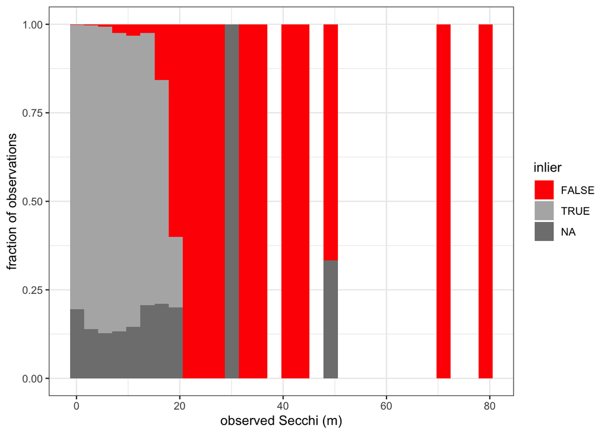

```r
ggplot(sdd_ransac_check, aes(x = harmonized_value, fill = is_inlier)) +
  geom_histogram(position = "fill", bins = 30) +
  scale_fill_manual(values = c(`TRUE` = "grey70", `FALSE` = "red")) +
  labs(x = "observed Secchi (m)", y = "fraction of observations",
       fill = "inlier") +
  theme_bw()
```

This all looks okay.

## Remote Sensing Filters

Scene-level metadata (cloud cover, image quality, geometric accuracy, etc.) isn’t carried through siteSR’s per-site aggregation, so we download it separately (via `00_download_AquaMatch_data.Rmd`) and join it on below via `sat_id`.

```r
scene_metadata_paths <- list.files(
  aquamatch_raw_data_dir,
  pattern = "sceneMetadata_Landsat(457|89)\\.csv$",
  full.names = TRUE
)

if (length(scene_metadata_paths) == 0) {
  stop("No scene-level metadata found in ", aquamatch_raw_data_dir,
       " - run 00_download_AquaMatch_data.Rmd first.")
}

# LS457 and LS89 have slightly different columns (e.g. a single
# IMAGE_QUALITY vs. split IMAGE_QUALITY_OLI/_TIRS), so bind_rows() unions
# them rather than assuming identical schemas
scene_metadata <- map(.x = scene_metadata_paths,
                      .f = ~ read_csv(., show_col_types = FALSE) %>%
                        filter(CLOUD_COVER < 20)) %>%
  bind_rows()
```

```r
sites_geom_qa <- read_csv(file.path(aquamatch_raw_data_dir, "siteSR_collated_WQP_NWIS_sites_with_NHD_info_2025-06-04.csv"),
                  show_col_types = FALSE) %>%
  # make sure the point extent only touches one waterbody
  filter(number_int_wb == 1) %>%
  select(siteSR_id, wb_nhd_id, wb_gnis_name, wb_areasqkm,
         flag_wb, flag_optical_shoreline,
         flag_thermal_TM_shoreline, flag_thermal_ETM_shoreline,
         flag_thermal_TIRS_shoreline, WGS84_Latitude, WGS84_Longitude)

# restrict to sites within our 6-state region's HUC4 footprint (see
# "Regional AOI" above) - none of the site-level QA below (de-duping,
# ransac) needs regional context, so scope down before it runs rather than
# waiting until 02_make_matches.Rmd to subset down after matching
sites <- sites_geom_qa %>%
  st_as_sf(coords = c("WGS84_Longitude", "WGS84_Latitude"), crs = 4326,
           remove = FALSE) %>%
  st_transform(st_crs(HUC4_filtered)) %>%
  st_join(HUC4_filtered %>% select(huc4), left = FALSE) %>%
  # guard against a site sitting exactly on a shared HUC4 boundary, which
  # could otherwise match more than one polygon in the spatial join above
  distinct(siteSR_id, .keep_all = TRUE) %>%
  st_drop_geometry()
```

Different `siteSR_id` values (different source prefixes - `WQP_*`, `AM_*`, `NWIS_*`, etc.) can still be the exact same physical monitoring location, or two locations close enough together that Landsat can’t tell them apart. Two sites within 100m of each other but assigned to *different* waterbodies aren’t the same location - that’s more likely two real, distinct water features close together (or an NHD assignment error) than one site measured twice - so sites are only collapsed together when they’re both within 100m of each other *and* share the same `wb_nhd_id`. Grouping is transitive (connected components over that adjacency), so a chain of near-duplicates collapses into a single `location_id` even if its two most-distant members are themselves more than 100m apart.

Note that we do *not* filter out shoreline-flagged sites here (`flag_wb`, `flag_optical_shoreline`, and the thermal shoreline flags are carried through, not filtered on) - shoreline proximity turns out to be a useful predictive feature rather than pure contamination, so a later script collapses these into a `shore_flag` feature instead of discarding the data.

```r
site_pts <- sites %>%
  st_as_sf(coords = c("WGS84_Longitude", "WGS84_Latitude"), crs = 4326,
           remove = FALSE)

# sparse adjacency: which sites (including itself) fall within 100m of
# each site
site_within_100m <- st_is_within_distance(site_pts, dist = 100)

# ...then restrict those pairs to ones sharing a waterbody - equality is
# symmetric, so this keeps the adjacency symmetric (if j survives in i's
# filtered neighbor list, i survives in j's) for the connected-components
# step below
wb_nhd_id <- sites$wb_nhd_id
site_within_100m_same_wb <- Map(
  function(nbrs, wb) nbrs[wb_nhd_id[nbrs] == wb],
  site_within_100m, wb_nhd_id
)

# connected components over that adjacency - this is what makes the
# grouping transitive rather than strictly pairwise
site_components <- components(
  graph_from_adj_list(site_within_100m_same_wb, mode = "all")
)$membership

pad <- nchar(as.character(max(site_components)))
sites <- sites %>%
  mutate(location_id = sprintf(paste0("loc_%0", pad, "d"), site_components))

# one row per de-duplicated location, listing the individual siteSR_id
# values collapsed into it
site_location_groups <- sites %>%
  summarize(n_sites = n(),
            siteSR_ids = list(siteSR_id),
            WGS84_Latitude = mean(WGS84_Latitude),
            WGS84_Longitude = mean(WGS84_Longitude),
            .by = location_id) %>%
  arrange(-n_sites)

print(paste0(nrow(site_location_groups %>% filter(n_sites > 1)), " locations have
             more than one site in the 100m area in the same waterbody"))
```

```
## [1] "3336 locations have\n             more than one site in the 100m area in the same waterbody"
```

```r
site_location_groups %>%
  filter(n_sites > 20)
```

```
## # A tibble: 4 × 5
##   location_id n_sites siteSR_ids WGS84_Latitude WGS84_Longitude
##   <chr>         <int> <list>              <dbl>           <dbl>
## 1 loc_0940         86 <chr [86]>           37.0           -111.
## 2 loc_1654         40 <chr [40]>           47.7           -117.
## 3 loc_1655         37 <chr [37]>           47.7           -117.
## 4 loc_1660         26 <chr [26]>           47.5           -117.
```

```r
# for locations with more than one siteSR_id within 100m (see
# site_location_groups above), keep just the first siteSR_id per
# location_id, so a duplicated physical site doesn't feed the filter below
# more than once
representative_sites <- sites %>%
  distinct(location_id, .keep_all = TRUE) %>%
  pull(siteSR_id)
```